# Multi-season occupancy models for assessing species trends

Jeffrey W. Doser

June 08, 2022

# Introduction

This vignette details `spOccupancy` functionality introduced in v0.4.0 to fit static, multi-season occupancy models. A primary goal of monitoring programs is often to document and understand trends in species occurrence over time, in addition to understanding how occurrence varies with covariates that vary across space and/or time. Until v0.4.0, `spOccupancy` functionality has focused solely in the spatial dimension. Here we introduce the functions `tPGOcc()` and `spTPGOcc()`, which fit nonspatial and spatial multi-season occurrence models, respectively, for assessing trends in species occurrence as well as the effects of spatially-varying and/or spatio-temporally varying covariates on occurrence.

Below, we first load the `spOccupancy` package, the `coda` package for some additional MCMC diagnostics, as well as the `stars` and `ggplot2` packages to create some basic plots of our results. We also set a seed so you can reproduce the same results we do.

```r
library(spOccupancy)
library(stars)
library(ggplot2)
set.seed(500)
```

# Data structure and example data set

As motivation, suppose we are interested in quantifying the trend in occurrence from 2010-2018 of the Red-eyed Vireo in the Hubbard Brook Experimental Forest (HBEF) located in New Hampshire, USA. As part of a long-term study of avian population and community dynamics at HBEF, trained observers perform 100m-radius point count surveys at 373 sites every year during the breeding season (May-June) since 1999. Most sites are sampled three times during each year, providing the necessary replication for use in an occupancy modeling framework. Observers record the total number of individuals of each species they observed during each point count survey. Here we will only use data from 2010-2018, and because we are interested in modeling occurence trends, we summarize the data into a detection (1) if at least one individual was observed, and a nondetection (0) if otherwise. For specific details on the data set, see the [Hubbard Brook website](https://portal.edirepository.org/nis/mapbrowse?scope=knb-lter-hbr&identifier=178) and Doser, Leuenberger, et al. (2022).

The data object `hbefTrends` contains the detection-nondetection data over the nine year period for 12 foliage-gleaning bird species. Below we load the data object, which is provided as part of the `spOccupancy` package, and take a look at its structure using `str()`.

```r
data(hbefTrends)
str(hbefTrends)
```

```
List of 4
 $ y       : num [1:12, 1:373, 1:9, 1:3] 0 0 0 1 0 0 1 0 0 0 ...
  ..- attr(*, "dimnames")=List of 4
  .. ..$ : chr [1:12] "AMRE" "BAWW" "BHVI" "BLBW" ...
  .. ..$ : chr [1:373] "1" "2" "3" "4" ...
  .. ..$ : chr [1:9] "2010" "2011" "2012" "2013" ...
  .. ..$ : chr [1:3] "1" "2" "3"
 $ occ.covs:List of 3
  ..$ elev       : num [1:373] 475 494 546 587 588 ...
  ..$ years      : int [1:373, 1:9] 2010 2010 2010 2010 2010 2010 2010 2010 2010 2010 ...
  ..$ site.effect: int [1:373] 1 2 3 4 5 6 7 8 9 10 ...
 $ det.covs:List of 2
  ..$ day: num [1:373, 1:9, 1:3] 159 159 159 159 159 159 159 159 159 159 ...
  .. ..- attr(*, "dimnames")=List of 3
  .. .. ..$ : chr [1:373] "1" "2" "3" "4" ...
  .. .. ..$ : chr [1:9] "2010" "2011" "2012" "2013" ...
  .. .. ..$ : chr [1:3] "1" "2" "3"
  ..$ tod: num [1:373, 1:9, 1:3] 335 322 359 377 395 410 448 462 479 500 ...
 $ coords  : num [1:373, 1:2] 280000 280000 280000 280001 280000 ...
  ..- attr(*, "dimnames")=List of 2
  .. ..$ : chr [1:373] "1" "2" "3" "4" ...
  .. ..$ : chr [1:2] "X" "Y"
```

We see the `hbefTrends` object is a list object similar to other data objects used in `spOccupancy` model fitting functions. The list is comprised of the detection-nondetection data (`y`), occurrence covariates (`occ.covs`), detection covariates (`det.covs`), and the spatial coordinates of each site (`coords`). Note that `coords` is only necessary for spatially-explicit multi-season models. Here we see the detection-nondetection data `y` is a four-dimensional array, with dimensions corresponding to species (12), sites (373), primary time periods (9), and replicates (3). Because we are only interested in working with a single species, we will create a new data object called `revi.data` that contains the same data as `hbefTrends`, but we will subset `y` to only include the Red-eyed Vireo (REVI).

```r
revi.data <- hbefTrends
sp.names <- dimnames(hbefTrends$y)[[1]]
revi.data$y <- revi.data$y[sp.names == 'REVI', , , ]
# Take a look at the new data object
str(revi.data)
```

```
List of 4
 $ y       : num [1:373, 1:9, 1:3] 0 0 0 1 0 1 0 1 1 0 ...
  ..- attr(*, "dimnames")=List of 3
  .. ..$ : chr [1:373] "1" "2" "3" "4" ...
  .. ..$ : chr [1:9] "2010" "2011" "2012" "2013" ...
  .. ..$ : chr [1:3] "1" "2" "3"
 $ occ.covs:List of 3
  ..$ elev       : num [1:373] 475 494 546 587 588 ...
  ..$ years      : int [1:373, 1:9] 2010 2010 2010 2010 2010 2010 2010 2010 2010 2010 ...
  ..$ site.effect: int [1:373] 1 2 3 4 5 6 7 8 9 10 ...
 $ det.covs:List of 2
  ..$ day: num [1:373, 1:9, 1:3] 159 159 159 159 159 159 159 159 159 159 ...
  .. ..- attr(*, "dimnames")=List of 3
  .. .. ..$ : chr [1:373] "1" "2" "3" "4" ...
  .. .. ..$ : chr [1:9] "2010" "2011" "2012" "2013" ...
  .. .. ..$ : chr [1:3] "1" "2" "3"
  ..$ tod: num [1:373, 1:9, 1:3] 335 322 359 377 395 410 448 462 479 500 ...
 $ coords  : num [1:373, 1:2] 280000 280000 280000 280001 280000 ...
  ..- attr(*, "dimnames")=List of 2
  .. ..$ : chr [1:373] "1" "2" "3" "4" ...
  .. ..$ : chr [1:2] "X" "Y"
```

Now the data are in the exact required format for fitting multi-season occupancy models in `spOccupancy`. The detection-nondetection data `y` is a three-dimensional array, with the first element corresponding to sites (373), the second element corresponding to primary time periods (in this case, 9 years), and the third element corresponding to replicates (3). The occurrence (`occ.covs`) and detection (`det.covs`) covariates are both lists comprised of the possible covariates we want to include on the occurrence and detection portion of the occupancy model, respectively. For multi-season models, occurrence covariates can vary across space and/or time, while detection covariates can vary across space, across time, across space and time, or across each individual observation (i.e., vary across space, time, and replicate).

For `occ.covs`, space varying covariates should be specified as a vector of length $J$, where $J$ is the total number of sites in the data set (in this case, 373). In `revi.data`, we see two site-level covariates. `elev` is the elevation of each site, and the `site.effect` is a variable that simply denotes the site number for each site. As we will see later, we can use the `site.effect` variable to include a non-spatial random effect of site in our models as a simple way to account for the non-independence of data points that come from the same site over the multiple primary time periods (i.e., years). The final covariate we have in `occ.covs` is `years`, which is the variable we will use to estimate a trend in occurrence. The variable `years` only varies over time, although we see that it is included in `occ.covs` as a matrix with rows corresponding to sites and columns corresponding to primary time periods (years). For covariates that only vary over time, `spOccupancy` requires that you specify them as a site x time period matrix, with the values within each year simply being constant. We can see this structure by taking a look at the first ten rows of `revi.data$occ.covs$years`.

```r
revi.data$occ.covs$years[1:10, ]
```

```
      [,1] [,2] [,3] [,4] [,5] [,6] [,7] [,8] [,9]
 [1,] 2010 2011 2012 2013 2014 2015 2016 2017 2018
 [2,] 2010 2011 2012 2013 2014 2015 2016 2017 2018
 [3,] 2010 2011 2012 2013 2014 2015 2016 2017 2018
 [4,] 2010 2011 2012 2013 2014 2015 2016 2017 2018
 [5,] 2010 2011 2012 2013 2014 2015 2016 2017 2018
 [6,] 2010 2011 2012 2013 2014 2015 2016 2017 2018
 [7,] 2010 2011 2012 2013 2014 2015 2016 2017 2018
 [8,] 2010 2011 2012 2013 2014 2015 2016 2017 2018
 [9,] 2010 2011 2012 2013 2014 2015 2016 2017 2018
[10,] 2010 2011 2012 2013 2014 2015 2016 2017 2018
```

This is the same format we would use to specify a covariate that varies over both space and time, except the elements would of course then vary across both rows and columns.

For the detection covariates in `det.covs`, we specify space-varying, time-varying, and spatio-temporally varying covariates in the same manner as just described for `occ.covs`. Additionally, we can have detection covariates that vary across space, time, and replicate. We refer to these as observation-level covariates. Observation-level covariates are specified as three-dimensional arrays, with the first dimension corresponding to sites, the second dimension corresponding to primary time periods, and the third dimension corresponding to replicates. Here, we have two observation-level covariates in `det.covs`: `day` (the specific day of the year the survey took place) and `tod` (the specific time of day the survey began, in minutes since midnight).

Finally, `coords` is a two-dimensional matrix of coordinates, with rows corresponding to sites, and two columns that contain the horizontal (i.e., easting) and vertical (i.e., northing) dimensions for each site. Note that `spOccupancy` requires coordinates to be specific in a projected coordinate system (i.e., these should not be longitude/latitude values).

# Model description

## Ecological process model

Let $z_{j, t}$ denote the presence (1) or absence (0) of a species at site $j$ and primary time period $t$, with $j = 1, \dots, J$ and $t = 1, \dots, T$. For our REVI example, $J = 373$ and $T = 9$, where the primary sampling periods are years. We assume this latent occurrence variable arises from a Bernoulli distribution following

$$\begin{equation}
\begin{split}
&z_{j, t} \sim \text{Bernoulli}(\psi_{j, t}), \\
&\text{logit}(\psi_{j, t}) = \beta_0 + \beta_1 \cdot \text{TIME}_t + \sum_{r = 2}^{p_{\psi}}x_{r, j, t} \cdot \beta_r,
\end{split}
\end{equation}$$

where $\psi_{j, t}$ is the probability of occurrence at site $j$ during time period $t$, $\beta_0$ is an intercept parameter, $\beta_1$ is a temporal trend parameter (where $TIME_t$ simply denotes the time period corresponding to $t$), and $\beta_r$ for $r = 2, \dots, p_{\psi}$ is the effect of some covariate $x_{r, j, t}$ that may vary over space and/or time. Note that here we have explicitly separated a trend parameter, as we view understanding trends in occurrence as a primary motivation for using `tPGOcc()` and `spTPGOcc()`. However, the trend component can be removed from the model if interest solely lies in understanding the effect of spatio-temporally varying covariates on occurrence, temporally-varying intercepts can be estimated instead of a trend parameter, or additional trend components can be included in the model to allow for additional flexibility (e.g., a quadratic trend component).

As our model for species occurrence is currently written, we are assuming independence among the repeated measurements at each site over the $T$ primary time periods (beyond that explained by the trend parameter and the spatiotemporally-varying covariates). This assumption may (likely) not be reasonable, as data points at the same point over time are likely more related to each other (i.e., correlated) compared to data points at different site and or time points. If such non-independence among data points exists and we fail to ignore it, our estimates of uncertainty would be too small. In the classical statistics literature, this is a phenomenon known as pseudoreplication (Hurlbert 1984). Depending on the study system, this may be an important phenomenon to address in our modeling approach.

The statistical ecology literature is filled with a variety of ways to accommodate such non-independence over time when modeling species occurrence (see Chapter 4 in Kéry and Royle (2021) for a lovely overview). Dynamic occupancy models and their numerous extensions model multi-season detection-nondetection data by explicitly modeling species occurrence through time as a function of initial occurrence, colonization, and persistence/extinction (MacKenzie et al. 2003). By modeling occurrence of a species in primary time period $t$ based on the previous time period in $t - 1$, these models clearly account for the fact that repeated measurements at a site over time are likely to be correlated. Such mechanistic, dynamic models are extremely valuable tools for understanding the processes governing species distributions in space and time. However, the standard dynamic occupancy model is not directly suited to model trends in occurrence over time as it does not explicitly estimate a trend parameter, which is often of key interest in monitoring programs. Further, the dynamic occupancy model can require large amounts of data (e.g., lots of sites and primary time periods) in order to separately estimate colonization and extinction/persistence dynamics. If we aren’t explicitly interested in the dynamics of the species and rather just seek to understand spatio-temporal patterns in species occurrence, we can account for non-independence in our repeated samples at a given site over time by including a random site effect into our model. We can extend our above model for the occurrence probability $\psi_{j, t}$ to become

$$\begin{equation}
\text{logit}(\psi_{j, t}) = \beta_0 + \beta_1 \cdot \text{TIME}_t + \text{w}_j + \sum_{r = 2}^{p_{\psi}}x_{r, j, t} \cdot \beta_r,
\end{equation}$$

where $\text{w}_j$ is a site-level random effect. By incorporating a random effect in this simple manner, we account for non-independence between repeated measurements at a given site over time, and thus our measurements of uncertainty are likely to be more accurate.

There are two ways in which we can include the site effects ($\text{w}_j$). First, we can assume the site effects are basic random intercepts, where we envision each $\text{w}_j$ is drawn from a Normal distribution with a mean of 0 and variance $\sigma^2_{\psi}$. This model can be fit using the `spOccupancy` function `tPGOcc()` by including random intercepts using `lme4` syntax (Bates et al. 2015). Alternatively, we can assign a spatial structure to the random effects and treat them as spatial random effects. By modeling the site-level random effects as spatial random effects, we not only account for the non-independence between repeated measurements at each site over time, but we can also account for residual spatial autocorrelation in species distributions, which is a common phenomenon when working across large spatial domains (Guélat and Kéry 2018). When there are a sufficient number of sites sampled in the data set, modeling the site-level effects as spatial random effects will likely improve both inference and prediction of species distributions (Guélat and Kéry 2018). The `spOccupancy` function `spTPGOcc()` fits such a model with spatially-structured random effects. We model the spatial random effects using Nearest Neighbor Gaussin Processes (Datta et al. 2016) to yield a computationally efficient implementation of these spatially-explicit models. See the [spOccupancy introductory vignette](https://www.jeffdoser.com/files/spoccupancy-web/articles/modelfitting) and Doser, Finley, et al. (2022) for specific details.

## Observation model

We do not directly observe $z_{j, t}$, but rather we observe an imperfect representation of the latent occurrence process as a result of imperfect detection (i.e., the failure to detect a species during a survey when it is truly present). Let $y_{j, t, k}$ be the observed detection (1) or nondetection (0) of a species of interest at site $j$ during primary time period $t$ during replicate $k$ for each of $k = 1, \dots, K_{j, t}$. Note that the number of replicates, $K_{j, t}$, can vary by site and primary time period. In practical applications, many sites will only be sampled during a subset of the total $T$ primary time periods, and so certain values of $K_{j, t}$ will be 0. For our REVI example, most sites are sampled during every year, and there is typically three surveys at each site during each year. We envision the detection-nondetection data as arising from a Bernoulli process conditional on the true latent occurrence process according to

$$\begin{equation}
\begin{split}
&y_{j, t, k} \sim \text{Bernoulli}(p_{j, t, k}z_{j, t}), \\
&\text{logit}(p_{j, t, k}) = \boldsymbol{v}^{\top}_{j, t, k}\boldsymbol{\alpha},
\end{split}
\end{equation}$$

where $p_{j, t, k}$ is the probability of detecting a species at site $j$ in primary time period $t$ during replicate $k$ (given it is present at site $j$ during time period $t$), which is a function of site, primary time period, and/or replicate specific covariates $\boldsymbol{V}$ and a vector of regression coefficients ($\boldsymbol{\alpha}$).

To complete the Bayesian specification of the model, we assign multivariate normal priors for the occurrence ($\boldsymbol{\beta}$) and detection ($\boldsymbol{\alpha}$) regression coefficients. For non-spatial random intercepts included in the occurrence or detection portions of the occupancy model, we assign an inverse-Gamma prior on the variance parameter. If spatial random effects are included in the ecological sub-model, we assign an inverse-Gamma prior to the spatial variance parameter, and a uniform prior to the spatial range and the spatial smoothness parameter. See Supporting Information S1 in Doser, Finley, et al. (2022) for more details on prior distributions used in `spOccupancy`.

# Fitting multi-season occupancy models with `tPGOcc()`

The function `tPGOcc()` fits multi-season single species occupancy models. `tPGOcc()` has the following arguments

```r
tPGOcc(occ.formula, det.formula, data, inits, priors, n.samples,
       n.omp.threads = 1, verbose = TRUE, n.report = 100,
       n.burn = round(.10 * n.samples), n.thin = 1, n.chains = 1,
       k.fold, k.fold.threads = 1, k.fold.seed, k.fold.only = TRUE, ...)
```

The arguments for `tPGOcc()` are identical to those used in all other non-spatial `spOccupancy` functions, and so we won’t go into too much detail on each argument and will focus on fitting the models (see [the introductory vignette](https://www.jeffdoser.com/files/spoccupancy-web/articles/modelfitting) for more specific details on function arguments). The first two arguments, `occ.formula` and `det.formula`, use standard R model syntax to specify the covariates to include in the occurrence and detection portions of the model, respectively. We only specify the right side of the formulas. We can include random intercepts in the occurrence and detection portion of the models using `lme4` syntax (Bates et al. 2015). We will see this clearly when we include a site-level random effect in the occurrence portion of our model for REVI. The `data` argument contains the necessary data for fitting the multi-season occupancy model. This should be a list object of the form previously described with our `revi.data` object. As a reminder, let’s take a look at the structure of `revi.data`

```r
str(revi.data)
```

```
List of 4
 $ y       : num [1:373, 1:9, 1:3] 0 0 0 1 0 1 0 1 1 0 ...
  ..- attr(*, "dimnames")=List of 3
  .. ..$ : chr [1:373] "1" "2" "3" "4" ...
  .. ..$ : chr [1:9] "2010" "2011" "2012" "2013" ...
  .. ..$ : chr [1:3] "1" "2" "3"
 $ occ.covs:List of 3
  ..$ elev       : num [1:373] 475 494 546 587 588 ...
  ..$ years      : int [1:373, 1:9] 2010 2010 2010 2010 2010 2010 2010 2010 2010 2010 ...
  ..$ site.effect: int [1:373] 1 2 3 4 5 6 7 8 9 10 ...
 $ det.covs:List of 2
  ..$ day: num [1:373, 1:9, 1:3] 159 159 159 159 159 159 159 159 159 159 ...
  .. ..- attr(*, "dimnames")=List of 3
  .. .. ..$ : chr [1:373] "1" "2" "3" "4" ...
  .. .. ..$ : chr [1:9] "2010" "2011" "2012" "2013" ...
  .. .. ..$ : chr [1:3] "1" "2" "3"
  ..$ tod: num [1:373, 1:9, 1:3] 335 322 359 377 395 410 448 462 479 500 ...
 $ coords  : num [1:373, 1:2] 280000 280000 280000 280001 280000 ...
  ..- attr(*, "dimnames")=List of 2
  .. ..$ : chr [1:373] "1" "2" "3" "4" ...
  .. ..$ : chr [1:2] "X" "Y"
```

Let’s first take a look at the average raw occurrence probabilities across sites within each year as a crude exploratory data analysis plot. This will give us an idea of how adequate a linear temporal trend is for our analysis.

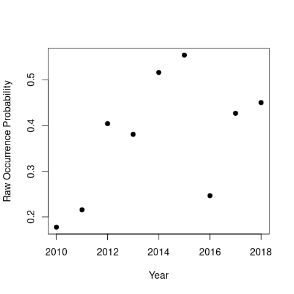

```r
raw.occ.prob <- apply(revi.data$y, 2, mean, na.rm = TRUE)
plot(2010:2018, raw.occ.prob, pch = 19,
     xlab = 'Year', ylab = 'Raw Occurrence Probability')
```

Quickly looking at this plot reveals what appears to be a positive trend in raw occurrence probability over the nine year period. Of course, there are some clear annual deviations from an overall trend (in particular in 2016). Also remember that this is the raw occurrence probability, which is a confounded process of true species occurrence and detection probability. Based on this plot, we will move forward with fitting a linear temporal trend in the occurrence model to summarize the overall pattern in occurrence probability over the nine year period.

More specifically, we will model REVI occurrence as a function of a linear temporal trend as well as a linear and quadratic effect of elevation. We will model detection as a function of day of survey (linear and quadratic) and time of day the survey began (linear). Note that for now we will not include any site-level random effect in our model. As per usual, we will standardize all covariates using the `scale()` function to help with model convergence. Note that the names in the formula must match up with names provided in the `occ.covs` and `det.covs` portions of the data list.

```r
revi.occ.formula <- ~ scale(years) + scale(elev) + I(scale(elev)^2)
revi.det.formula <- ~ scale(day) + I(scale(day)^2) + scale(tod)
```

Below we specify the initial values for all model parameters. Note that the initial values for the latent occurrence probabilities (`z`) should be a matrix with rows corresponding to sites and columns corresponding to primary time periods. We set our initial values in `z` to 1 if the species was detected at any of the replicates at a given site/time period and 0 otherwise (this is also what `spOccupancy` does by default).

```r
z.inits <- apply(revi.data$y, c(1, 2), function(a) as.numeric(sum(a, na.rm = TRUE) > 0))
revi.inits <- list(beta = 0, alpha = 0, z = z.inits)
```

We specify priors in the `priors` argument. Here we set priors for the occurrence and detection regression coefficients to vague normal priors (which are also the default values, so we could just not do this).

```r
revi.priors <- list(beta.normal = list(mean = 0, var = 2.72),
                    alpha.normal = list(mean = 0, var = 2.72))
```

Finally, we specify the number of MCMC chains (`n.chains`), samples (`n.samples`), the amount of burn-in (`n.burn`), and our thinning rate (`n.thin`).

```r
n.chains <- 3
n.samples <- 5000
n.burn <- 2000
n.thin <- 12
```

We are now set to run the model with `tPGOcc()`. We set `n.report = 1000` to report model progress after every 1000th iteration.

```r
out <- tPGOcc(occ.formula = revi.occ.formula,
              det.formula = revi.det.formula,
              data = revi.data,
              n.samples = n.samples,
              inits = revi.inits,
              priors = revi.priors,
              n.burn = n.burn,
              n.thin = n.thin,
              n.chains = n.chains,
              n.report = 1000)
```

```
----------------------------------------
    Preparing the data
----------------------------------------
```

```
There are missing values in data$y with corresponding non-missing values in data$det.covs.
Removing these site/year/replicate combinations for fitting the model.
```

```
----------------------------------------
    Model description
----------------------------------------
Trend Occupancy Model with Polya-Gamma latent
variable fit with 373 sites and 9 years.

Samples per Chain: 5000
Burn-in: 2000
Thinning Rate: 12
Number of Chains: 3
Total Posterior Samples: 750

Source compiled with OpenMP support and model fit using 1 thread(s).

----------------------------------------
    Chain 1
----------------------------------------
Sampling ...
Sampled: 1000 of 5000, 20.00%
-------------------------------------------------
Sampled: 2000 of 5000, 40.00%
-------------------------------------------------
Sampled: 3000 of 5000, 60.00%
-------------------------------------------------
Sampled: 4000 of 5000, 80.00%
-------------------------------------------------
Sampled: 5000 of 5000, 100.00%
----------------------------------------
    Chain 2
----------------------------------------
Sampling ...
Sampled: 1000 of 5000, 20.00%
-------------------------------------------------
Sampled: 2000 of 5000, 40.00%
-------------------------------------------------
Sampled: 3000 of 5000, 60.00%
-------------------------------------------------
Sampled: 4000 of 5000, 80.00%
-------------------------------------------------
Sampled: 5000 of 5000, 100.00%
----------------------------------------
    Chain 3
----------------------------------------
Sampling ...
Sampled: 1000 of 5000, 20.00%
-------------------------------------------------
Sampled: 2000 of 5000, 40.00%
-------------------------------------------------
Sampled: 3000 of 5000, 60.00%
-------------------------------------------------
Sampled: 4000 of 5000, 80.00%
-------------------------------------------------
Sampled: 5000 of 5000, 100.00%
```

Note the message about missing values in `data$y` and `data$det.covs`. All `spOccupancy` model fitting functions check for discrepancies in the missing values between the detection-nondetection data points and the occurrence and detection covariate values. In this case, there are missing detection-nondetection data points in certain site/time period/replicate combinations where there are non-missing values in the detection covariates. `tPGOcc()` kindly informs us that these combinations are not used when the model is fit. In other scenarios where `spOccupancy` encounters missing values (e.g., missing values in `data$occ.covs`), you will receive an error with information on potential ways to handle the missing values.

As with all `spOccupancy` model functions, we can use `summary()` to get a quick summary of model results and convergence diagnostics (i.e., Gelman-Rubin diagnostic and effective sample size).

```r
summary(out)
```

```
Call:
tPGOcc(occ.formula = revi.occ.formula, det.formula = revi.det.formula,
    data = revi.data, inits = revi.inits, priors = revi.priors,
    n.samples = n.samples, n.report = 1000, n.burn = n.burn,
    n.thin = n.thin, n.chains = n.chains)

Samples per Chain: 5000
Burn-in: 2000
Thinning Rate: 12
Number of Chains: 3
Total Posterior Samples: 750
Run Time (min): 0.9104

Occurrence (logit scale):
                    Mean     SD    2.5%     50%   97.5%   Rhat ESS
(Intercept)       1.5394 0.0896  1.3757  1.5336  1.7346 1.0073 750
scale(years)      0.5586 0.0637  0.4377  0.5592  0.6801 1.0029 750
scale(elev)      -1.1803 0.0647 -1.3059 -1.1815 -1.0551 1.0083 750
I(scale(elev)^2) -0.4879 0.0477 -0.5827 -0.4864 -0.3992 1.0349 750

Detection (logit scale):
                   Mean     SD    2.5%     50%  97.5%   Rhat ESS
(Intercept)      0.1521 0.0441  0.0648  0.1534 0.2384 1.0040 750
scale(day)      -0.0106 0.0268 -0.0637 -0.0099 0.0410 1.0286 750
I(scale(day)^2) -0.0074 0.0276 -0.0621 -0.0079 0.0474 1.0063 750
scale(tod)      -0.0148 0.0258 -0.0631 -0.0161 0.0389 1.0074 750
```

Taking a quick look, we see adequate convergence of all parameters (i.e., Rhats are all less than 1.1 and ESS values are sufficiently large). In this model, we don’t include any site effect to account for potential correlation in occurrence over the multiple time periods at each given site. We see a positive trend in occurrence probability, which matches with the EDA plot we produced earlier. As we discussed in the model description section, a simple way to account for this potential correlation is to include a random site-level effect in the model. We do this below and take a look at the results from the new model. Note that we set `verbose = FALSE` to suppress information on model progress.

```r
out.site.re <- tPGOcc(occ.formula = ~ scale(years) + scale(elev) + I(scale(elev)^2) +
                                      (1 | site.effect),
                      det.formula = revi.det.formula,
                      data = revi.data,
                      n.samples = n.samples,
                      inits = revi.inits,
                      priors = revi.priors,
                      n.burn = n.burn,
                      n.thin = n.thin,
                      n.chains = n.chains,
                      verbose = FALSE)
summary(out.site.re)
```

```
Call:
tPGOcc(occ.formula = ~scale(years) + scale(elev) + I(scale(elev)^2) +
    (1 | site.effect), det.formula = revi.det.formula, data = revi.data,
    inits = revi.inits, priors = revi.priors, n.samples = n.samples,
    verbose = FALSE, n.burn = n.burn, n.thin = n.thin, n.chains = n.chains)

Samples per Chain: 5000
Burn-in: 2000
Thinning Rate: 12
Number of Chains: 3
Total Posterior Samples: 750
Run Time (min): 1.1963

Occurrence (logit scale):
                    Mean     SD    2.5%     50%   97.5%   Rhat ESS
(Intercept)       1.8584 0.1535  1.5734  1.8495  2.1792 1.0150 400
scale(years)      0.6746 0.0766  0.5374  0.6734  0.8211 1.0046 750
scale(elev)      -1.4429 0.1165 -1.6752 -1.4399 -1.2091 1.0036 551
I(scale(elev)^2) -0.5874 0.0891 -0.7623 -0.5835 -0.4130 1.0225 645

Occurrence Random Effect Variances (logit scale):
              Mean     SD   2.5%   50%  97.5%   Rhat ESS
site.effect 2.0899 0.3721 1.4589 2.047 2.8884 1.0166 358

Detection (logit scale):
                   Mean     SD    2.5%     50%  97.5%   Rhat ESS
(Intercept)      0.1853 0.0420  0.1065  0.1835 0.2732 1.0023 750
scale(day)      -0.0079 0.0282 -0.0666 -0.0072 0.0441 1.0017 750
I(scale(day)^2) -0.0053 0.0278 -0.0593 -0.0055 0.0489 1.0156 750
scale(tod)      -0.0195 0.0256 -0.0689 -0.0193 0.0286 1.0097 750
```

Immediately, we see the site random effect variance is fairly large, indicating there is substantial correlation in the occurrence states at a given site over the 9 year period that this random effect is accounting for. We see slight differences in the occurrence covariate effects compared to the model without the site-level random effect. In particular, our uncertainty is larger in the model that does include the site-level random effect. This is exactly what we expect.

We can also do a more formal model comparison with the `waicOcc()` function, which calculates the WAIC (Watanabe 2010) for any model object in `spOccupancy`.

```r
waicOcc(out)
```

```
        elpd           pD         WAIC
-5167.783059     7.936806 10351.439730
```

```r
waicOcc(out.site.re)
```

```
      elpd         pD       WAIC
-4856.6722   194.0123 10101.3690
```

We see adding in the site-level random effect substantially reduces the WAIC, suggesting there is additional variation across the sites that is an important source of variability in the data.

Next, let’s perform a Goodness of Fit assessment by performing a posterior predictive check on the two models. We do this using the `ppcOcc()` function. Because posterior predictive checks are not valid for binary responses (McCullagh 2019), we group the data across sites (`group = 1`) and use the Freeman-Tukey statistic as a fit statistic. The `summary()` function provides us with a Bayesian p-value for the entire data set, as well as for each time period to give an indication on how our model fits the data points across each time period.

```r
# No site-level random effect
ppc.out <- ppcOcc(out, fit.stat = 'freeman-tukey', group = 1)
```

```
Currently on time period 1 out of 9
```

```
Currently on time period 2 out of 9
```

```
Currently on time period 3 out of 9
```

```
Currently on time period 4 out of 9
```

```
Currently on time period 5 out of 9
```

```
Currently on time period 6 out of 9
```

```
Currently on time period 7 out of 9
```

```
Currently on time period 8 out of 9
```

```
Currently on time period 9 out of 9
```

```r
summary(ppc.out)
```

```
Call:
ppcOcc(object = out, fit.stat = "freeman-tukey", group = 1)

Samples per Chain: 5000
Burn-in: 2000
Thinning Rate: 12
Number of Chains: 3
Total Posterior Samples: 750

----------------------------------------
    All time periods
----------------------------------------
Bayesian p-value:  0.5084

----------------------------------------
    Individual time periods
----------------------------------------
Time Period 1 Bayesian p-value: 0.016
Time Period 2 Bayesian p-value: 0.2507
Time Period 3 Bayesian p-value: 0.9213
Time Period 4 Bayesian p-value: 0.6413
Time Period 5 Bayesian p-value: 0.9787
Time Period 6 Bayesian p-value: 1
Time Period 7 Bayesian p-value: 0
Time Period 8 Bayesian p-value: 0.4373
Time Period 9 Bayesian p-value: 0.3307
Fit statistic:  freeman-tukey
```

```r
# Site-level random effect
ppc.out.site.re <- ppcOcc(out.site.re, fit.stat = 'freeman-tukey', group = 1)
```

```
Currently on time period 1 out of 9
```

```
Currently on time period 2 out of 9
```

```
Currently on time period 3 out of 9
```

```
Currently on time period 4 out of 9
```

```
Currently on time period 5 out of 9
```

```
Currently on time period 6 out of 9
```

```
Currently on time period 7 out of 9
```

```
Currently on time period 8 out of 9
```

```
Currently on time period 9 out of 9
```

```r
summary(ppc.out.site.re)
```

```
Call:
ppcOcc(object = out.site.re, fit.stat = "freeman-tukey", group = 1)

Samples per Chain: 5000
Burn-in: 2000
Thinning Rate: 12
Number of Chains: 3
Total Posterior Samples: 750

----------------------------------------
    All time periods
----------------------------------------
Bayesian p-value:  0.5747

----------------------------------------
    Individual time periods
----------------------------------------
Time Period 1 Bayesian p-value: 0.008
Time Period 2 Bayesian p-value: 0.272
Time Period 3 Bayesian p-value: 0.9907
Time Period 4 Bayesian p-value: 0.7013
Time Period 5 Bayesian p-value: 0.996
Time Period 6 Bayesian p-value: 1
Time Period 7 Bayesian p-value: 0
Time Period 8 Bayesian p-value: 0.748
Time Period 9 Bayesian p-value: 0.456
Fit statistic:  freeman-tukey
```

We see for both models the overall Bayesian p-value is close to 0.5, indicating adequate overall model fit. However, when looking at the Bayesian p-values for individual time periods, we see that a few of the values are either very close to 1 or close to 0, indicating that in certain time periods our model underestimates the data, while in other time periods our model overestimates the data. This really is not all that surprising given that we are only using a linear trend to explain temporal variation in the occurrence probability over the 9 year period. Occurrence probability almost surely does not exactly follow a linear trend over the 9 year period, and rather there will be certain years that fluctuate from this overall trend and have either on average a higher occurrence probability or a lower occurrence probability. When we fit a model with a linear trend, we don’t necessarily care about these seasonal fluctuations, and rather are just interested in the overall trend across the entire time period. To get a further understanding of what’s going on here, we can look back at the plot of time vs. raw occurrence proability and imagine fitting a linear trend through the figure, which would represent our predicted values from the model. Across the figure, some points would fall above the line, and others would fall below. If the point fell well below the line, the Bayesian p-value would be close to 0. If the point fell well above the line, the Bayesian p-value would be close to 1. Looking back at our yearly Bayesian p-values, we see that our p-values are very low for years 2010 and 2016, whereas the p-values are very high for years 2012, 2014, and 2015. Looking at the plot, these are exactly the years where the raw occurrence probabilities fall well below and above our imaginary trend line, respectively. Because there is no consistent pattern in the under or overestimation, we can feel pretty confident about this model if our goal is simply to estimate the trend.

However, if we want to more accurately characterize the annual fluctations in the data, we can follow Kéry and Royle (2021) and add in a random effect of year, which will account for any deviations in yearly occurrence probabilities from the trend line. Convergence and mixing of this model is slower than for the previous models, which is not suprising given that we are now estimating two random effects.

```r
out.year.site.re <- tPGOcc(occ.formula = ~ scale(years) + scale(elev) +
                                           I(scale(elev)^2) +
                                           (1 | site.effect) + (1 | years),
                           det.formula = revi.det.formula,
                           data = revi.data,
                           n.samples = n.samples,
                           inits = revi.inits,
                           priors = revi.priors,
                           n.burn = n.burn,
                           n.thin = n.thin,
                           n.chains = n.chains,
                           n.report = 1000,
                           verbose = FALSE)
summary(out.year.site.re)
```

```
Call:
tPGOcc(occ.formula = ~scale(years) + scale(elev) + I(scale(elev)^2) +
    (1 | site.effect) + (1 | years), det.formula = revi.det.formula,
    data = revi.data, inits = revi.inits, priors = revi.priors,
    n.samples = n.samples, verbose = FALSE, n.report = 1000,
    n.burn = n.burn, n.thin = n.thin, n.chains = n.chains)

Samples per Chain: 5000
Burn-in: 2000
Thinning Rate: 12
Number of Chains: 3
Total Posterior Samples: 750
Run Time (min): 1.34

Occurrence (logit scale):
                    Mean     SD    2.5%     50%   97.5%   Rhat ESS
(Intercept)       1.8655 0.4477  0.9902  1.8478  2.8134 1.4151  46
scale(years)      0.5102 0.3976 -0.2801  0.5240  1.2041 1.2620  53
scale(elev)      -1.6106 0.1285 -1.8545 -1.6087 -1.3567 1.0009 446
I(scale(elev)^2) -0.6925 0.0899 -0.8644 -0.6934 -0.5082 1.0331 795

Occurrence Random Effect Variances (logit scale):
              Mean     SD   2.5%    50%  97.5%   Rhat ESS
site.effect 2.7118 0.4298 1.9413 2.6762 3.6053 0.9995 456
years       1.8118 1.1795 0.5300 1.4587 5.0138 1.0341 605

Detection (logit scale):
                   Mean     SD    2.5%     50%  97.5%   Rhat ESS
(Intercept)      0.2151 0.0420  0.1315  0.2161 0.2962 1.0316 750
scale(day)      -0.0137 0.0265 -0.0614 -0.0146 0.0396 1.0409 750
I(scale(day)^2) -0.0037 0.0283 -0.0587 -0.0048 0.0549 1.0150 750
scale(tod)      -0.0272 0.0273 -0.0823 -0.0260 0.0250 1.0083 764
```

```r
# No random effects
waicOcc(out)
```

```
        elpd           pD         WAIC
-5167.783059     7.936806 10351.439730
```

```r
# Site random effects
waicOcc(out.site.re)
```

```
      elpd         pD       WAIC
-4856.6722   194.0123 10101.3690
```

```r
# Site and year random effects
waicOcc(out.year.site.re)
```

```
      elpd         pD       WAIC
-4704.7613   216.9313  9843.3851
```

Incorporating the year random effects in addition to the site random effects yielded substantial decreases in WAIC. As the final part of our model assessment and comparison, we take a look at the Bayesian p-values

```r
ppc.out.year.site <- ppcOcc(out.year.site.re, fit.stat = 'freeman-tukey', group = 1)
```

```
Currently on time period 1 out of 9
```

```
Currently on time period 2 out of 9
```

```
Currently on time period 3 out of 9
```

```
Currently on time period 4 out of 9
```

```
Currently on time period 5 out of 9
```

```
Currently on time period 6 out of 9
```

```
Currently on time period 7 out of 9
```

```
Currently on time period 8 out of 9
```

```
Currently on time period 9 out of 9
```

```r
summary(ppc.out.year.site)
```

```
Call:
ppcOcc(object = out.year.site.re, fit.stat = "freeman-tukey",
    group = 1)

Samples per Chain: 5000
Burn-in: 2000
Thinning Rate: 12
Number of Chains: 3
Total Posterior Samples: 750

----------------------------------------
    All time periods
----------------------------------------
Bayesian p-value:  0.6551

----------------------------------------
    Individual time periods
----------------------------------------
Time Period 1 Bayesian p-value: 0.3667
Time Period 2 Bayesian p-value: 0.4427
Time Period 3 Bayesian p-value: 0.6467
Time Period 4 Bayesian p-value: 0.512
Time Period 5 Bayesian p-value: 0.9027
Time Period 6 Bayesian p-value: 0.8787
Time Period 7 Bayesian p-value: 0.5547
Time Period 8 Bayesian p-value: 0.9347
Time Period 9 Bayesian p-value: 0.6573
Fit statistic:  freeman-tukey
```

Looking at the individual Bayesian p-values for each time period, we see many of them are much less extreme than our analysis without the year random effect. This is a result of the random year effects accounting for any yearly deviations from the overall linear trend line.

Finally, we will conclude this section by predicting REVI occurrence probability across the entire Hubbard Brook forest. The object `hbefEelev` (which comes as part of the `spOccupancy` package) contains elevation data at a 30x30m resolution from the National Elevation Data set across the entire HBEF. We load the data below

```r
data(hbefElev)
str(hbefElev)
```

```
'data.frame':   46090 obs. of  3 variables:
 $ val     : num  914 916 918 920 922 ...
 $ Easting : num  276273 276296 276318 276340 276363 ...
 $ Northing: num  4871424 4871424 4871424 4871424 4871424 ...
```

Below we will predict occurrence in the first (2010) and last (2018) year of our data set for the entire HBEF. Given that we standardized the elevation and year values when we fit the model, we need to standardize both covariates for prediction using the exact same values of the mean and standard deviation of the values used to fit the model. We set the `ignore.RE = TRUE` to only perform prediction with the fixed effects.

```r
# Number of prediction sites.
J.pred <- nrow(hbefElev)
# Number of prediction years.
n.years.pred <- 2
# Number of predictors (including intercept)
p.occ <- ncol(out.year.site.re$beta.samples)
# Get covariates and standardize them using values used to fit the model
elev.pred <- (hbefElev$val - mean(revi.data$occ.covs$elev)) / sd(revi.data$occ.covs$elev)
year.pred <- matrix(rep((c(2010, 2018) - mean(revi.data$occ.covs$years)) / sd(revi.data$occ.covs$years),
                    length(elev.pred)), J.pred, n.years.pred, byrow = TRUE)
# Create three-dimensional array
X.0 <- array(1, dim = c(J.pred, n.years.pred, p.occ))
# Fill in the array
# Years
X.0[, , 2] <- year.pred
# Elevation
X.0[, , 3] <- elev.pred
# Elevation^2
X.0[, , 4] <- elev.pred^2
# Check out the structure
str(X.0)
```

```
 num [1:46090, 1:2, 1:4] 1 1 1 1 1 1 1 1 1 1 ...
```

```r
out.pred <- predict(out.year.site.re, X.0,
                    ignore.RE = TRUE, type = 'occupancy')
# Check out the structure
str(out.pred)
```

```
List of 5
 $ psi.0.samples: num [1:750, 1:46090, 1:2] 0.006 0.00943 0.00854 0.01112 0.01328 ...
 $ z.0.samples  : int [1:750, 1:46090, 1:2] 0 0 0 0 0 0 0 0 0 0 ...
 $ run.time     : 'proc_time' Named num [1:5] 9.06 2.15 9.93 0 0
  ..- attr(*, "names")= chr [1:5] "user.self" "sys.self" "elapsed" "user.child" ...
 $ call         : language predict.tPGOcc(object = out.year.site.re, X.0 = X.0, ignore.RE = TRUE,      type = "occupancy")
 $ object.class : chr "tPGOcc"
 - attr(*, "class")= chr "predict.tPGOcc"
```

We see the `out.pred` object is a list with two main components: `psi.0.samples` (the occurrence probability predictions) and `z.0.samples` (the latent occurrence predictions). Both objects are three-dimensional arrays with dimensions corresponding to MCMC sample, site, and primary time period, respectively. Below we plot the mean and sd of REVI occurrence probability in 2018 across the forest.

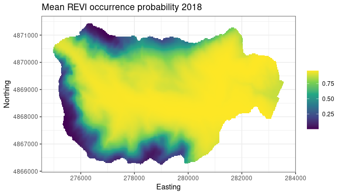

```r
plot.dat <- data.frame(x = hbefElev$Easting,
                       y = hbefElev$Northing,
                       mean.psi = apply(out.pred$psi.0.samples[, , 2], 2, mean),
                       sd.psi = apply(out.pred$psi.0.samples[, , 2], 2, sd),
                       stringsAsFactors = FALSE)
# Make a species distribution map showing the point estimates,
# or predictions (posterior means)
dat.stars <- st_as_stars(plot.dat, dims = c('x', 'y'))
ggplot() +
  geom_stars(data = dat.stars, aes(x = x, y = y, fill = mean.psi)) +
  scale_fill_viridis_c(na.value = 'transparent') +
  labs(x = 'Easting', y = 'Northing', fill = '',
       title = 'Mean REVI occurrence probability 2018') +
  theme_bw()
```

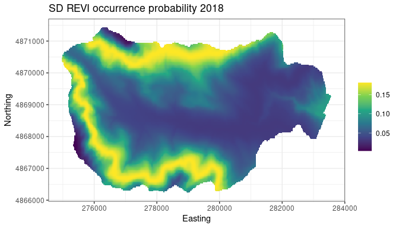

```r
# Map of the associated uncertainty of these predictions
# (i.e., posterior sds)
ggplot() +
  geom_stars(data = dat.stars, aes(x = x, y = y, fill = sd.psi)) +
  scale_fill_viridis_c(na.value = 'transparent') +
  labs(x = 'Easting', y = 'Northing', fill = '',
       title = 'SD REVI occurrence probability 2018') +
  theme_bw()
```

# Fitting spatially-explicit multi-season occupancy models with `spTPGOcc()`

Instead of including a random site effect as an unstructured random effect to account for the multiple measurements at the same site over the $T$ primary time periods, we can use a spatially-structured random effect. This provides us with the additional benefit of accounting for spatial autocorrelation across the sites, which if present can lead to overly precise and potentially inaccurate estimates of species occurrence (Guélat and Kéry 2018). As we discussed in the model description section, in `spOccupancy` we incorporate such spatial random effects into our model using the `spTPGOcc()` and use Nearest Neighbor Gaussian Processes (Datta et al. 2016) to ensure models are computationally efficient even when modeling over a large number of spatial locations.

In the previous section, we saw our model for REVI with a random site effect and a random year effect was the most supported model according to the WAIC. Here we will extend this model to now incoporate a spatially-structured random effect.

The function `spTPGOcc()` has similar arguments to `tPGOcc()` and exactly the same arguments as the `spPGOcc()` function for fitting single season spatial occupancy models:

```r
spTPGOcc(occ.formula, det.formula, data, inits, priors,
         tuning, cov.model = 'exponential', NNGP = TRUE,
         n.neighbors = 15, search.type = 'cb', n.batch,
         batch.length, accept.rate = 0.43,
         n.omp.threads = 1, verbose = TRUE, n.report = 100,
         n.burn = round(.10 * n.batch * batch.length),
         n.thin = 1, n.chains = 1, k.fold, k.fold.threads = 1,
         k.fold.seed = 100, ...)
```

Because the arguments of `spTPGOcc()` are identical to other spatially-explicit functions in `spOccupancy`, we won’t go into all that much detail on them here, and rather encourage you to look at [the introductory vignette](https://www.jeffdoser.com/files/spoccupancy-web/articles/modelfitting) for more specific details, in particular the section on single-species spatial occupancy models.

The `occ.formula`, `det.formula`, and `data` arguments all take the same form as what we saw previously for `tPGOcc()`, with the exception that we are now required to include the spatial coordinates in the `data` object as a matrix with rows corresponding to sites and columns containing the easting and northing coordinates of each site. Notice in `occ.formula` we remove the non-spatial random effect for site (`(1 | site.effect)`), as `spTPGOcc()` will incorporate a spatial random effect into the model instead.

```r
revi.sp.occ.formula <- ~ scale(years) + scale(elev) + I(scale(elev)^2) +
                         (1 | years)
revi.sp.det.formula <- ~ scale(day) + I(scale(day)^2) + scale(tod)
# Remind ourselves of the format of the data
str(revi.data)
```

```
List of 4
 $ y       : num [1:373, 1:9, 1:3] 0 0 0 1 0 1 0 1 1 0 ...
  ..- attr(*, "dimnames")=List of 3
  .. ..$ : chr [1:373] "1" "2" "3" "4" ...
  .. ..$ : chr [1:9] "2010" "2011" "2012" "2013" ...
  .. ..$ : chr [1:3] "1" "2" "3"
 $ occ.covs:List of 3
  ..$ elev       : num [1:373] 475 494 546 587 588 ...
  ..$ years      : int [1:373, 1:9] 2010 2010 2010 2010 2010 2010 2010 2010 2010 2010 ...
  ..$ site.effect: int [1:373] 1 2 3 4 5 6 7 8 9 10 ...
 $ det.covs:List of 2
  ..$ day: num [1:373, 1:9, 1:3] 159 159 159 159 159 159 159 159 159 159 ...
  .. ..- attr(*, "dimnames")=List of 3
  .. .. ..$ : chr [1:373] "1" "2" "3" "4" ...
  .. .. ..$ : chr [1:9] "2010" "2011" "2012" "2013" ...
  .. .. ..$ : chr [1:3] "1" "2" "3"
  ..$ tod: num [1:373, 1:9, 1:3] 335 322 359 377 395 410 448 462 479 500 ...
 $ coords  : num [1:373, 1:2] 280000 280000 280000 280001 280000 ...
  ..- attr(*, "dimnames")=List of 2
  .. ..$ : chr [1:373] "1" "2" "3" "4" ...
  .. ..$ : chr [1:2] "X" "Y"
```

Below we specify the initial values for all model parameters. This is the same as what we did for `tPGOcc()`, except we now also specify an initial value for the paramter that controls the spatial range and decay (`phi`) as well as the spatial variance (`sigma.sq`). Notice the initial value for the spatial decay parameter `phi` is set to a value of 3 divided by the mean distance between points, which corresponds to setting the effective range of spatial autocorrelation to the average distance between points (Banerjee, Carlin, and Gelfand 2003).

```r
z.inits <- apply(revi.data$y, c(1, 2), function(a) as.numeric(sum(a, na.rm = TRUE) > 0))
# Pair-wise distance between all sites
dist.hbef <- dist(revi.data$coords)
revi.sp.inits <- list(beta = 0, alpha = 0, z = z.inits,
                      sigma.sq = 1, phi = 3 / mean(dist.hbef))
```

We specify priors in the `priors` argument just as we saw with `tPGOcc()`. We use an inverse-Gamma prior for the spatial variance `sigma.sq` and a uniform prior for the spatial range parameter `phi`.

```r
revi.sp.priors <- list(beta.normal = list(mean = 0, var = 2.72),
                       alpha.normal = list(mean = 0, var = 2.72),
                       sigma.sq.ig = c(2, 1),
                       phi.unif = c(3 / max(dist.hbef), 3 / min(dist.hbef)))
```

Next we specify parameters associated with the spatial random effects. In particular, we set `cov.model = 'exponential'` to use an exponential spatial correlation function and `n.neighbors = 5` to use an NNGP with 5 nearest neighbors.

```r
cov.model <- 'exponential'
n.neighbors <- 5
```

Finally, we set the arguments that control how long we run the MCMC. For all spatially-explicit models in `spOccupancy`, instead of specifying an argument with the total number of samples (`n.samples`), we split the samples into a set of `n.batch` batches, each comprised of a length of `batch.length`. This is because we use an adaptive algorithm to improve mixing of the MCMC chains for the spatial range parameter. We will run the model for 5000 samples, comprised of 200 batches each of length 25. We specify a burn-in period of 2000 iterations and a thinning rate of 12. See [the introductory vignette](https://www.jeffdoser.com/files/spoccupancy-web/articles/modelfitting) for more details on the adaptive algorithm.

```r
n.batch <- 200
batch.length <- 25
# Total number of samples
n.batch * batch.length
```

```
[1] 5000
```

```r
n.burn <- 2000
n.thin <- 12
```

We now run the model with `spTPGOcc()` and take a look at a summary of the results using `summary()`.

```r
# Approximate Run Time: 5 min
out.sp <- spTPGOcc(occ.formula = revi.sp.occ.formula,
                   det.formula = revi.sp.det.formula,
                   data = revi.data,
                   inits = revi.sp.inits,
                   priors = revi.sp.priors,
                   cov.model = cov.model,
                   n.neighbors = n.neighbors,
                   n.batch = n.batch,
                   batch.length = batch.length,
                   verbose = TRUE,
                   n.report = 50,
                   n.burn = n.burn,
                   n.thin = n.thin,
                   n.chains = 3)
```

```
----------------------------------------
    Preparing the data
----------------------------------------
```

```
There are missing values in data$y with corresponding non-missing values in data$det.covs.
Removing these site/year/replicate combinations for fitting the model.
```

```
No prior specified for sigma.sq.psi.ig.
Setting prior shape to 0.1 and prior scale to 0.1
```

```
sigma.sq.psi is not specified in initial values.
Setting initial values to random values between 0.5 and 10
```

```
----------------------------------------
    Building the neighbor list
----------------------------------------
----------------------------------------
Building the neighbors of neighbors list
----------------------------------------
----------------------------------------
    Model description
----------------------------------------
Spatial NNGP Trend Occupancy Model with Polya-Gamma latent
variable fit with 373 sites and 9 years.

Samples per chain: 5000 (200 batches of length 25)
Burn-in: 2000
Thinning Rate: 12
Number of Chains: 3
Total Posterior Samples: 750

Using the exponential spatial correlation model.

Using 5 nearest neighbors.

Source compiled with OpenMP support and model fit using 1 thread(s).

Adaptive Metropolis with target acceptance rate: 43.0
----------------------------------------
    Chain 1
----------------------------------------
Sampling ...
Batch: 50 of 200, 25.00%
    Parameter   Acceptance  Tuning
    phi     16.0        0.61263
-------------------------------------------------
Batch: 100 of 200, 50.00%
    Parameter   Acceptance  Tuning
    phi     40.0        0.40252
-------------------------------------------------
Batch: 150 of 200, 75.00%
    Parameter   Acceptance  Tuning
    phi     52.0        0.32303
```

[output cut: 21 more lines]

```
----------------------------------------
Sampling ...
Batch: 50 of 200, 25.00%
    Parameter   Acceptance  Tuning
    phi     44.0        0.29229
-------------------------------------------------
Batch: 100 of 200, 50.00%
    Parameter   Acceptance  Tuning
    phi     60.0        0.28083
-------------------------------------------------
Batch: 150 of 200, 75.00%
    Parameter   Acceptance  Tuning
    phi     32.0        0.31037
-------------------------------------------------
Batch: 200 of 200, 100.00%
```

```r
summary(out.sp)
```

```
Call:
spTPGOcc(occ.formula = revi.sp.occ.formula, det.formula = revi.sp.det.formula,
    data = revi.data, inits = revi.sp.inits, priors = revi.sp.priors,
    cov.model = cov.model, n.neighbors = n.neighbors, n.batch = n.batch,
    batch.length = batch.length, verbose = TRUE, n.report = 50,
    n.burn = n.burn, n.thin = n.thin, n.chains = 3)

Samples per Chain: 5000
Burn-in: 2000
Thinning Rate: 12
Number of Chains: 3
Total Posterior Samples: 750
Run Time (min): 1.3107

Occurrence (logit scale):
                    Mean     SD    2.5%     50%   97.5%   Rhat ESS
(Intercept)       1.8375 0.4329  1.0436  1.8343  2.7896 1.1702  78
scale(years)      0.5577 0.6803 -1.7110  0.6283  1.5953 1.5981  18
scale(elev)      -1.5163 0.1957 -1.8882 -1.5058 -1.1508 1.1010 216
I(scale(elev)^2) -0.7523 0.1462 -1.0404 -0.7503 -0.4602 1.0296 273

Occurrence Random Effect Variances (logit scale):
        Mean     SD   2.5%    50%  97.5%   Rhat ESS
years 2.1393 2.5247 0.6217 1.5545 7.3597 1.7383  47

Detection (logit scale):
                   Mean     SD    2.5%     50%  97.5%   Rhat ESS
(Intercept)      0.2189 0.0415  0.1412  0.2171 0.2986 1.0076 750
scale(day)      -0.0089 0.0269 -0.0618 -0.0095 0.0458 1.0095 891
I(scale(day)^2) -0.0032 0.0280 -0.0551 -0.0040 0.0544 1.0045 886
scale(tod)      -0.0279 0.0271 -0.0812 -0.0265 0.0240 1.0080 750

Spatial Covariance:
           Mean     SD   2.5%    50%  97.5%   Rhat ESS
sigma.sq 2.6897 0.5199 1.8344 2.6377 3.8014 1.0006 329
phi      0.0033 0.0007 0.0020 0.0033 0.0049 1.0082 265
```

As with `tPGOcc()`, we can do model assessment using `ppcOcc()` and prediction using `predict()`, which we do not show here for the sake of brevity. We will note the only exception for prediction is that the coordinates of the new sites must also be sent into the `predict()` function. See `?predict.spTPGOcc()` for details.

Below we compare the model with spatially-explicit random effects to that with non-spatial site-level random effects using WAIC.

```r
# Non-spatial random effects
waicOcc(out.year.site.re)
```

```
      elpd         pD       WAIC
-4704.7613   216.9313  9843.3851
```

```r
# Spatial random effects
waicOcc(out.sp)
```

```
      elpd         pD       WAIC
-4717.2042   174.6965  9783.8014
```

We see a substantial decrease in WAIC, suggesting that incorporation of the spatial structure into the site-level random effects improved model fit.

In addition to WAIC, both `tPGOcc()` and `spTPGOcc()` allow for performing k-fold cross-validation as an assessment of model predictive performance. Comparing predictive performance using out-of-sample data can provide us with better insight on which model out of a set of candidate models performs better for prediction, whereas WAIC (and other information criteria) provide us with an idea of which model fits the data the better, and thus may be more suitable if inference is the desired objective. We use the model deviance as our scoring rule for the cross-validation (Hooten and Hobbs 2015).

```r
# Non-spatial
k.fold.non.sp <- tPGOcc(occ.formula = ~ scale(years) + scale(elev) +
                                        I(scale(elev)^2) +
                                        (1 | site.effect) + (1 | years),
                        det.formula = revi.det.formula,
                        data = revi.data,
                        n.samples = n.batch * batch.length,
                        inits = revi.inits,
                        priors = revi.priors,
                        n.burn = n.burn,
                        n.thin = n.thin,
                        n.chains = n.chains,
                        n.report = 1000,
                        verbose = FALSE,
                        k.fold = 4,
                        k.fold.threads = 4,
                        k.fold.only = TRUE)
# Spatial
k.fold.sp <- spTPGOcc(occ.formula = revi.sp.occ.formula,
                      det.formula = revi.sp.det.formula,
                      data = revi.data,
                      inits = revi.sp.inits,
                      priors = revi.sp.priors,
                      cov.model = cov.model,
                      n.neighbors = n.neighbors,
                      n.batch = n.batch,
                      batch.length = batch.length,
                      verbose = TRUE,
                      n.report = 50,
                      n.burn = n.burn,
                      n.thin = n.thin,
                      n.chains = 3,
                      k.fold = 4,
                      k.fold.threads = 4,
                      k.fold.only = TRUE)
```

```
----------------------------------------
    Preparing the data
----------------------------------------
```

```
There are missing values in data$y with corresponding non-missing values in data$det.covs.
Removing these site/year/replicate combinations for fitting the model.
```

```
No prior specified for sigma.sq.psi.ig.
Setting prior shape to 0.1 and prior scale to 0.1
```

```
sigma.sq.psi is not specified in initial values.
Setting initial values to random values between 0.5 and 10
```

```
----------------------------------------
    Building the neighbor list
----------------------------------------
----------------------------------------
Building the neighbors of neighbors list
----------------------------------------
----------------------------------------
    Cross-validation
----------------------------------------
```

```
Performing 4-fold cross-validation using 4 thread(s).
```

```r
str(k.fold.sp)
```

```
List of 2
 $ k.fold.deviance: num 10222
 $ run.time       : 'proc_time' Named num [1:5] 0.218 0.208 40.333 175.036 65.555
  ..- attr(*, "names")= chr [1:5] "user.self" "sys.self" "elapsed" "user.child" ...
 - attr(*, "class")= chr "spTPGOcc"
```

```r
k.fold.non.sp$k.fold.deviance
```

```
[1] 10399.65
```

```r
k.fold.sp$k.fold.deviance
```

```
[1] 10222.24
```

# References

Banerjee, Sudipto, Bradley P Carlin, and Alan E Gelfand. 2003. *Hierarchical Modeling and Analysis for Spatial Data*. Chapman; Hall/CRC.

Bates, Douglas, Martin Mächler, Ben Bolker, and Steve Walker. 2015. “Fitting Linear Mixed-Effects Models Using lme4.” *Journal of Statistical Software* 67 (1): 1–48. https://doi.org/10.18637/jss.v067.i01.

Datta, Abhirup, Sudipto Banerjee, Andrew O Finley, and Alan E Gelfand. 2016. “Hierarchical Nearest-Neighbor Gaussian Process Models for Large Geostatistical Datasets.” *Journal of the American Statistical Association* 111 (514): 800–812.

Doser, Jeffrey W, Andrew O Finley, Marc Kéry, and Elise F Zipkin. 2022. “spOccupancy: An R package for single-species, multi-species, and integrated spatial occupancy models.” *Methods in Ecology and Evolution*.

Doser, Jeffrey W, Wendy Leuenberger, T Scott Sillett, Michael T Hallworth, and Elise F Zipkin. 2022. “Integrated Community Occupancy Models: A Framework to Assess Occurrence and Biodiversity Dynamics Using Multiple Data Sources.” *Methods in Ecology and Evolution*.

Guélat, Jérôme, and Marc Kéry. 2018. “Effects of Spatial Autocorrelation and Imperfect Detection on Species Distribution Models.” *Methods in Ecology and Evolution* 9 (6): 1614–25.

Hooten, Mevin B, and N Thompson Hobbs. 2015. “A Guide to Bayesian Model Selection for Ecologists.” *Ecological Monographs* 85 (1): 3–28.

Hurlbert, Stuart H. 1984. “Pseudoreplication and the Design of Ecological Field Experiments.” *Ecological Monographs* 54 (2): 187–211.

Kéry, Marc, and J Andrew Royle. 2021. *Applied Hierarchical Modeling in Ecology: Analysis of Distribution, Abundance, and Species Richness in R and Bugs: Volume 2: Dynamic and Advanced Models.* London, UK: Academic Press.

MacKenzie, Darryl I, James D Nichols, James E Hines, Melinda G Knutson, and Alan B Franklin. 2003. “Estimating Site Occupancy, Colonization, and Local Extinction When a Species Is Detected Imperfectly.” *Ecology* 84 (8): 2200–2207.

McCullagh, Peter. 2019. “Generalized Linear Models.”

Polson, Nicholas G, James G Scott, and Jesse Windle. 2013. “Bayesian Inference for Logistic Models Using Pólya–Gamma Latent Variables.” *Journal of the American Statistical Association* 108 (504): 1339–49.

Watanabe, Sumio. 2010. “Asymptotic Equivalence of Bayes Cross Validation and Widely Applicable Information Criterion in Singular Learning Theory.” *Journal of Machine Learning Research* 11 (12).